# HouseSellingPrices

some of my notes on what i’m doing are in the comments inside the code chunks, but i’ll admit, since this draft is really rough, most of my notes are in my notebook, a few notecards, and an excel doc.

im not sure if i did this right and there are some parts i wasn’t sure how to do, but i worked on it this week, so i wanted to turn in what i have

```r
#https://rmarkdown.rstudio.com/lesson-3.html#:~:text=To%20set%20global%20options%20that,overwritten%20in%20individual%20chunk%20headers.
knitr::opts_chunk$set(warning = FALSE, message = FALSE)
```

### instructions

Create a file called HouseSellingPrices.Rmd in RStudio.

Click to download a copy of the data Download download a copy of the data for this assignment.

Click here to download a full_pairs_plot.png of the data.

Build a regression model that accurately predicts house “SalePrice” (your Y-variable, see the Overview for details.)

Show your work. Explain your logic as you create your model using the train.csv data. Interpret the coefficients from your final model. Validate your model using this code:

```r
# set.seed(121)
#
# num_rows <- 1000 #1460 total
# keep <- sample(1:nrow(train), num_rows)
#
# mytrain <- train[keep, ] #Use this in the lm(..., data=mytrain)
#
# mytest <- train[-keep, ] #Use this in the predict(..., newdata=mytest)
```

Find some way to visually present your final model, even if it is just one dimension at a time.

Submit your final html file to this dropbox by the deadline.

### project

```r
library(mosaic)
library(tidyverse)
library(pander)
library(ggplot2)

houseData <- read.csv("train.csv")
relevantColcsv <- read.csv("columnsThatLookRelevant.csv")
houses <- houseData %>%
  select(relevantColcsv$columnsThatLookRelevant)
```

```r
#https://stackoverflow.com/questions/20364450/find-names-of-columns-which-contain-missing-values
#names(which(sapply(dfname, anyNA)))

houses <- houses %>%
  mutate(Alley = replace_na(Alley, "None")) %>%
  mutate(BsmtQual = replace_na(BsmtQual, "None")) %>%
  mutate(GarageType = replace_na(GarageType, "None")) %>%
  mutate(MasVnrArea = replace_na(MasVnrArea, 0)) %>%
  mutate(LotFrontage = replace_na(LotFrontage, 0)) %>%
  mutate(GarageYrBlt = replace_na(GarageYrBlt, 0))
```

```r
houselm1 <- lm(SalePrice ~ ., data=houses)
summary(houselm1) %>%
  pander()
```

|  | Estimate | Std. Error | t value | Pr(>\|t\|) |
| --- | --- | --- | --- | --- |
| **(Intercept)** | -262054 | 204687 | -1.28 | 0.2007 |
| **LotFrontage** | -10.19 | 26.89 | -0.379 | 0.7047 |
| **AlleyNone** | -171.9 | 5271 | -0.03262 | 0.974 |
| **AlleyPave** | -6294 | 7426 | -0.8475 | 0.3969 |
| **LotShapeIR2** | 13143 | 5206 | 2.525 | 0.0117 |
| **LotShapeIR3** | -24048 | 10346 | -2.324 | 0.02025 |
| **LotShapeReg** | -1684 | 2001 | -0.8417 | 0.4001 |
| **NeighborhoodBlueste** | -13789 | 23592 | -0.5845 | 0.559 |
| **NeighborhoodBrDale** | -15235 | 12152 | -1.254 | 0.2102 |
| **NeighborhoodBrkSide** | 2014 | 10149 | 0.1985 | 0.8427 |
| **NeighborhoodClearCr** | 13977 | 10435 | 1.339 | 0.1807 |
| **NeighborhoodCollgCr** | 7616 | 8141 | 0.9355 | 0.3497 |
| **NeighborhoodCrawfor** | 24119 | 9997 | 2.413 | 0.01597 |
| **NeighborhoodEdwards** | -14785 | 9162 | -1.614 | 0.1068 |
| **NeighborhoodGilbert** | 11332 | 8825 | 1.284 | 0.1994 |
| **NeighborhoodIDOTRR** | -11149 | 10788 | -1.033 | 0.3016 |
| **NeighborhoodMeadowV** | -23559 | 12929 | -1.822 | 0.06866 |
| **NeighborhoodMitchel** | -10824 | 9427 | -1.148 | 0.2511 |
| **NeighborhoodNAmes** | -7473 | 8900 | -0.8397 | 0.4012 |
| **NeighborhoodNoRidge** | 60482 | 9767 | 6.193 | 7.828e-10 |
| **NeighborhoodNPkVill** | -13986 | 18032 | -0.7756 | 0.4381 |
| **NeighborhoodNridgHt** | 35590 | 8877 | 4.009 | 6.419e-05 |
| **NeighborhoodNWAmes** | -7150 | 9173 | -0.7795 | 0.4358 |
| **NeighborhoodOldTown** | -15651 | 9808 | -1.596 | 0.1108 |
| **NeighborhoodSawyer** | -6332 | 9318 | -0.6795 | 0.4969 |
| **NeighborhoodSawyerW** | 4970 | 8956 | 0.5549 | 0.579 |
| **NeighborhoodSomerst** | 21732 | 8689 | 2.501 | 0.0125 |
| **NeighborhoodStoneBr** | 51223 | 10292 | 4.977 | 7.296e-07 |
| **NeighborhoodSWISU** | -10354 | 11383 | -0.9096 | 0.3632 |
| **NeighborhoodTimber** | 18301 | 9425 | 1.942 | 0.05237 |

[output cut: 76 more lines]

Fitting linear model: SalePrice ~ .

| Observations | Residual Std. Error | $R^2$ | Adjusted $R^2$ |
| --- | --- | --- | --- |
| 1460 | 30634 | 0.862 | 0.8513 |

```r
medPriceNbhd <- houses %>%
  group_by(Neighborhood) %>%
  summarise(medPrice = median(as.numeric(SalePrice)))

firstQ <- quantile(medPriceNbhd$medPrice, 0.25)
thirdQ <- quantile(medPriceNbhd$medPrice, 0.75)

medPriceNbhd <- medPriceNbhd %>%
  mutate(
    priceRange = case_when(
      medPrice <= firstQ ~ "Poor",
      medPrice >= thirdQ ~ "Rich",
      medPrice > firstQ & medPrice < thirdQ ~ "Middle"
    )
  )

PoorNbhd <- medPriceNbhd %>%
  filter(priceRange == "Poor") %>%
  select(Neighborhood)

MidNbhd <- medPriceNbhd %>%
  filter(priceRange == "Middle") %>%
  select(Neighborhood)

RichNbhd <- medPriceNbhd %>%
  filter(priceRange == "Rich") %>%
  select(Neighborhood)

houses <- houses %>%
  mutate(
    NbhdPriceRange = case_when(
      Neighborhood %in% PoorNbhd$Neighborhood ~ "Poor",
      Neighborhood %in% MidNbhd$Neighborhood ~ "Middle",
      Neighborhood %in% RichNbhd$Neighborhood ~ "Rich"
    ))

#https://www.listendata.com/2015/06/r-keep-drop-columns-from-data-frame.html
houses <- houses %>%
  select(-c(Neighborhood))
```

```r
houselm2 <- lm(SalePrice ~ ., data=houses)
summary(houselm2) %>%
  pander()
```

|  | Estimate | Std. Error | t value | Pr(>\|t\|) |
| --- | --- | --- | --- | --- |
| **(Intercept)** | -357886 | 187403 | -1.91 | 0.05638 |
| **LotFrontage** | -5.354 | 26.91 | -0.199 | 0.8423 |
| **AlleyNone** | 3366 | 5060 | 0.6652 | 0.506 |
| **AlleyPave** | -8572 | 7176 | -1.195 | 0.2325 |
| **LotShapeIR2** | 16184 | 5263 | 3.075 | 0.002147 |
| **LotShapeIR3** | -27484 | 10542 | -2.607 | 0.00923 |
| **LotShapeReg** | -4518 | 1957 | -2.309 | 0.02109 |
| **HouseStyle1.5Unf** | 21509 | 9778 | 2.2 | 0.02798 |
| **HouseStyle1Story** | 18451 | 4621 | 3.993 | 6.875e-05 |
| **HouseStyle2.5Fin** | -24560 | 15145 | -1.622 | 0.1051 |
| **HouseStyle2.5Unf** | -17671 | 10625 | -1.663 | 0.0965 |
| **HouseStyle2Story** | -10391 | 3880 | -2.678 | 0.007489 |
| **HouseStyleSFoyer** | 15088 | 6962 | 2.167 | 0.03039 |
| **HouseStyleSLvl** | 9798 | 5863 | 1.671 | 0.09492 |
| **OverallQual** | 11003 | 1209 | 9.101 | 3.063e-19 |
| **OverallCond** | 4919 | 992.4 | 4.957 | 8.056e-07 |
| **YearBuilt** | 183.5 | 79.14 | 2.319 | 0.02056 |
| **YearRemodAdd** | 85.17 | 69.4 | 1.227 | 0.2199 |
| **Exterior1stAsphShn** | -30392 | 42226 | -0.7197 | 0.4718 |
| **Exterior1stBrkComm** | -23938 | 30596 | -0.7824 | 0.4341 |
| **Exterior1stBrkFace** | 12036 | 15367 | 0.7832 | 0.4336 |
| **Exterior1stCBlock** | -8518 | 34145 | -0.2495 | 0.803 |
| **Exterior1stCemntBd** | 16837 | 23907 | 0.7043 | 0.4814 |
| **Exterior1stHdBoard** | -10865 | 15331 | -0.7087 | 0.4787 |
| **Exterior1stImStucc** | -29629 | 36444 | -0.813 | 0.4164 |
| **Exterior1stMetalSd** | -9490 | 17825 | -0.5324 | 0.5945 |
| **Exterior1stPlywood** | -9424 | 15063 | -0.6256 | 0.5317 |
| **Exterior1stStone** | -23077 | 28665 | -0.805 | 0.4209 |
| **Exterior1stStucco** | -7904 | 17148 | -0.4609 | 0.6449 |
| **Exterior1stVinylSd** | -23190 | 16089 | -1.441 | 0.1497 |

[output cut: 54 more lines]

Fitting linear model: SalePrice ~ .

| Observations | Residual Std. Error | $R^2$ | Adjusted $R^2$ |
| --- | --- | --- | --- |
| 1460 | 31447 | 0.8522 | 0.8433 |

```r
#after doing 24 lms, this one and the first one have the best R^2 but 21 is still the best bc everything is significant
```

```r
keepCol <- read.csv("housekeep.csv")
houses2 <- houses %>%
  select(c(SalePrice,keepCol$Keep))
houses3 <- houses %>%
  select(c(SalePrice, keepCol$Keep, ExterQual, GarageType))
```

```r
houselm3 <- lm(SalePrice ~ ., data=houses2)
summary(houselm3) %>%
  pander()
```

|  | Estimate | Std. Error | t value | Pr(>\|t\|) |
| --- | --- | --- | --- | --- |
| **(Intercept)** | 95191 | 126547 | 0.7522 | 0.452 |
| **LotShapeIR2** | 17729 | 6056 | 2.927 | 0.003472 |
| **LotShapeIR3** | -10101 | 11970 | -0.8439 | 0.3989 |
| **LotShapeReg** | -8874 | 2165 | -4.098 | 4.398e-05 |
| **HouseStyle1.5Unf** | -18964 | 10317 | -1.838 | 0.06625 |
| **HouseStyle1Story** | -12743 | 3676 | -3.466 | 0.000543 |
| **HouseStyle2.5Fin** | 30440 | 13608 | 2.237 | 0.02545 |
| **HouseStyle2.5Unf** | 262.2 | 11735 | 0.02234 | 0.9822 |
| **HouseStyle2Story** | -15.03 | 3833 | -0.003922 | 0.9969 |
| **HouseStyleSFoyer** | -27200 | 7222 | -3.767 | 0.0001722 |
| **HouseStyleSLvl** | -15975 | 5773 | -2.767 | 0.005725 |
| **OverallQual** | 19436 | 1244 | 15.63 | 5.852e-51 |
| **OverallCond** | 3292 | 998.5 | 3.298 | 0.0009993 |
| **YearBuilt** | -6.112 | 63.36 | -0.09647 | 0.9232 |
| **MasVnrArea** | 35.32 | 6.27 | 5.633 | 2.125e-08 |
| **BsmtQualFa** | -44413 | 8730 | -5.088 | 4.108e-07 |
| **BsmtQualGd** | -34192 | 4541 | -7.53 | 8.925e-14 |
| **BsmtQualNone** | -30172 | 8368 | -3.606 | 0.0003222 |
| **BsmtQualTA** | -39848 | 5498 | -7.247 | 6.921e-13 |
| **BsmtFinSF1** | 22.61 | 2.462 | 9.185 | 1.4e-19 |
| **BsmtFinSF2** | 19.15 | 6.193 | 3.093 | 0.002021 |
| **KitchenQualFa** | -40823 | 8259 | -4.943 | 8.596e-07 |
| **KitchenQualGd** | -37112 | 4721 | -7.861 | 7.42e-15 |
| **KitchenQualTA** | -48153 | 5228 | -9.211 | 1.115e-19 |
| **GarageArea** | 54.38 | 5.921 | 9.185 | 1.406e-19 |
| **WoodDeckSF** | 50.31 | 8.33 | 6.04 | 1.958e-09 |
| **ScreenPorch** | 65.47 | 17.82 | 3.675 | 0.0002469 |
| **NbhdPriceRangePoor** | -11841 | 2779 | -4.261 | 2.167e-05 |
| **NbhdPriceRangeRich** | 24046 | 2914 | 8.251 | 3.538e-16 |

Fitting linear model: SalePrice ~ .

| Observations | Residual Std. Error | $R^2$ | Adjusted $R^2$ |
| --- | --- | --- | --- |
| 1460 | 36792 | 0.7896 | 0.7855 |

```r
#why is LotShapeIR1 missing and NbhdPriceRangeMiddle?
#484 rows of IR1 and 716 of Middle, so it's not bc there's nothing there
#https://stackoverflow.com/questions/28195996/count-number-of-rows-matching-a-criteria
#nrow(dat[dat$sCode == "CA",])
```

```r
houselm4 <- lm(SalePrice ~ ., data=houses3)
summary(houselm4) %>%
  pander()
```

|  | Estimate | Std. Error | t value | Pr(>\|t\|) |
| --- | --- | --- | --- | --- |
| **(Intercept)** | 297548 | 130219 | 2.285 | 0.02246 |
| **LotShapeIR2** | 16891 | 5956 | 2.836 | 0.004637 |
| **LotShapeIR3** | -18121 | 11813 | -1.534 | 0.1253 |
| **LotShapeReg** | -7649 | 2125 | -3.599 | 0.0003306 |
| **HouseStyle1.5Unf** | -18205 | 10097 | -1.803 | 0.07159 |
| **HouseStyle1Story** | -12647 | 3627 | -3.487 | 0.0005033 |
| **HouseStyle2.5Fin** | 26901 | 13454 | 2 | 0.04574 |
| **HouseStyle2.5Unf** | 3097 | 11538 | 0.2684 | 0.7884 |
| **HouseStyle2Story** | -1295 | 3765 | -0.344 | 0.7309 |
| **HouseStyleSFoyer** | -26256 | 7139 | -3.678 | 0.000244 |
| **HouseStyleSLvl** | -20069 | 5788 | -3.467 | 0.0005413 |
| **OverallQual** | 17522 | 1282 | 13.67 | 4.808e-40 |
| **OverallCond** | 3414 | 991.3 | 3.444 | 0.0005895 |
| **YearBuilt** | -121.6 | 64.75 | -1.878 | 0.06053 |
| **MasVnrArea** | 30.57 | 6.23 | 4.907 | 1.03e-06 |
| **BsmtQualFa** | -37977 | 8656 | -4.387 | 1.231e-05 |
| **BsmtQualGd** | -29620 | 4633 | -6.393 | 2.196e-10 |
| **BsmtQualNone** | -25044 | 8255 | -3.034 | 0.002459 |
| **BsmtQualTA** | -33969 | 5542 | -6.129 | 1.141e-09 |
| **BsmtFinSF1** | 22.98 | 2.452 | 9.372 | 2.687e-20 |
| **BsmtFinSF2** | 20.05 | 6.088 | 3.293 | 0.001015 |
| **KitchenQualFa** | -35115 | 8460 | -4.151 | 3.508e-05 |
| **KitchenQualGd** | -30153 | 4971 | -6.066 | 1.681e-09 |
| **KitchenQualTA** | -38225 | 5512 | -6.935 | 6.142e-12 |
| **GarageArea** | 71.37 | 6.869 | 10.39 | 1.994e-24 |
| **WoodDeckSF** | 44.69 | 8.216 | 5.44 | 6.273e-08 |
| **ScreenPorch** | 65.29 | 17.48 | 3.735 | 0.0001951 |
| **NbhdPriceRangePoor** | -11169 | 2789 | -4.004 | 6.539e-05 |
| **NbhdPriceRangeRich** | 24375 | 2908 | 8.383 | 1.223e-16 |
| **ExterQualFa** | -27058 | 13196 | -2.051 | 0.0405 |
| **ExterQualGd** | -15810 | 6772 | -2.335 | 0.0197 |
| **ExterQualTA** | -22861 | 7455 | -3.067 | 0.002206 |
| **GarageTypeAttchd** | 37633 | 15371 | 2.448 | 0.01447 |
| **GarageTypeBasment** | 40411 | 17515 | 2.307 | 0.02118 |
| **GarageTypeBuiltIn** | 56477 | 15932 | 3.545 | 0.0004054 |
| **GarageTypeCarPort** | 18216 | 19622 | 0.9284 | 0.3534 |
| **GarageTypeDetchd** | 24286 | 15346 | 1.583 | 0.1137 |
| **GarageTypeNone** | 48951 | 16602 | 2.949 | 0.003245 |

Fitting linear model: SalePrice ~ .

| Observations | Residual Std. Error | $R^2$ | Adjusted $R^2$ |
| --- | --- | --- | --- |
| 1460 | 35965 | 0.8002 | 0.795 |

```r
houses4 <- houses3 %>%
  #House Style Mutations
  mutate(
    HouseStyleA = ifelse(HouseStyle == "1Story", "1Story", "Other"),
         HouseStyleB = case_when(
           HouseStyle %in% c("1Story","1.5Fin","1.5Unf","SFoyer","SLvl") ~ "1+Story",
           HouseStyle %in% c("2Story","2.5Unf","2.5Fin") ~ "2+Story"
         )
  ) %>%
  #Lot Shape Mutations
  mutate(
    LotShapeA = case_when(
    LotShape %in% c("Reg","IR1") ~ "PrettyReg",
    LotShape %in% c("IR2","IR3") ~ "Irreg"),
    LotShapeB = ifelse(LotShape == "Reg", "Regular", "Irregular")
  ) %>%
  #Garage Mutations
  mutate(
    GarageA = ifelse(GarageType == "None", "No", "Yes"),
    GarageB = case_when(
      GarageType == "None" ~ "None",
      GarageType == "CarPort" ~ "CarPort",
      GarageType != "CarPort" & GarageType != "None" ~ "Inside"),
    GarageC = ifelse(GarageType %in% c("CarPort","None"), "Outdoors", "Indoors")
    )

houses4 <- houses4 %>%
  select(-c(HouseStyle,LotShape,GarageType))

#decided after I ran lm5
houses4 <- houses4 %>%
  select(-c(MasVnrArea,GarageArea))

#decided after ran alphabet lm
houses4 <- houses4 %>%
  select(-c(YearBuilt))
```

```r
houses5 <- houses3 %>%
  mutate(
    masonry = ifelse(MasVnrArea == 0, "No", "Yes"),
    finbsmt2 = ifelse(BsmtFinSF2 == 0, "No", "Yes"),
    garageyn = ifelse(GarageArea == 0, "No", "Yes"),
    wooddeck = ifelse(WoodDeckSF == 0, "No", "Yes"),
    screenporch = ifelse(ScreenPorch == 0, "No", "Yes")
  ) %>%
  select(-c(MasVnrArea,BsmtFinSF2,GarageArea,WoodDeckSF,ScreenPorch))
```

```r
houselm5 <- lm(SalePrice ~ ., data=houses5)
summary(houselm5) %>%
  pander()
```

|  | Estimate | Std. Error | t value | Pr(>\|t\|) |
| --- | --- | --- | --- | --- |
| **(Intercept)** | 279908 | 139190 | 2.011 | 0.04452 |
| **LotShapeIR2** | 18699 | 6349 | 2.945 | 0.003282 |
| **LotShapeIR3** | -19013 | 12604 | -1.509 | 0.1316 |
| **LotShapeReg** | -9252 | 2257 | -4.098 | 4.398e-05 |
| **HouseStyle1.5Unf** | -22441 | 10748 | -2.088 | 0.03699 |
| **HouseStyle1Story** | -10890 | 3858 | -2.823 | 0.004826 |
| **HouseStyle2.5Fin** | 39861 | 14266 | 2.794 | 0.005273 |
| **HouseStyle2.5Unf** | -2991 | 12270 | -0.2437 | 0.8075 |
| **HouseStyle2Story** | 1627 | 4003 | 0.4065 | 0.6845 |
| **HouseStyleSFoyer** | -23908 | 7588 | -3.151 | 0.001662 |
| **HouseStyleSLvl** | -16098 | 6189 | -2.601 | 0.00939 |
| **OverallQual** | 21067 | 1344 | 15.68 | 3.098e-51 |
| **OverallCond** | 2517 | 1053 | 2.392 | 0.0169 |
| **YearBuilt** | -79.01 | 69.13 | -1.143 | 0.2533 |
| **BsmtQualFa** | -40387 | 9217 | -4.382 | 1.262e-05 |
| **BsmtQualGd** | -36348 | 4905 | -7.411 | 2.143e-13 |
| **BsmtQualNone** | -25727 | 8790 | -2.927 | 0.003477 |
| **BsmtQualTA** | -39822 | 5891 | -6.76 | 2.01e-11 |
| **BsmtFinSF1** | 29.11 | 2.542 | 11.45 | 4.124e-29 |
| **KitchenQualFa** | -39565 | 8989 | -4.401 | 1.156e-05 |
| **KitchenQualGd** | -29932 | 5292 | -5.656 | 1.873e-08 |
| **KitchenQualTA** | -39963 | 5859 | -6.821 | 1.337e-11 |
| **NbhdPriceRangePoor** | -11592 | 2977 | -3.894 | 0.0001033 |
| **NbhdPriceRangeRich** | 28390 | 3075 | 9.234 | 9.181e-20 |
| **ExterQualFa** | -26309 | 14013 | -1.877 | 0.06067 |
| **ExterQualGd** | -23367 | 7122 | -3.281 | 0.001059 |
| **ExterQualTA** | -31141 | 7872 | -3.956 | 7.999e-05 |
| **GarageTypeAttchd** | 2151 | 15945 | 0.1349 | 0.8927 |
| **GarageTypeBasment** | 1847 | 18252 | 0.1012 | 0.9194 |
| **GarageTypeBuiltIn** | 20929 | 16566 | 1.263 | 0.2067 |
| **GarageTypeCarPort** | -14139 | 20589 | -0.6867 | 0.4924 |
| **GarageTypeDetchd** | -10121 | 15978 | -0.6335 | 0.5265 |
| **GarageTypeNone** | -13843 | 16513 | -0.8383 | 0.402 |
| **masonryYes** | 2628 | 2400 | 1.095 | 0.2738 |
| **finbsmt2Yes** | 6823 | 3294 | 2.071 | 0.03852 |
| **wooddeckYes** | 7265 | 2219 | 3.274 | 0.001086 |
| **screenporchYes** | 11063 | 3816 | 2.899 | 0.003802 |

Fitting linear model: SalePrice ~ .

| Observations | Residual Std. Error | $R^2$ | Adjusted $R^2$ |
| --- | --- | --- | --- |
| 1460 | 38279 | 0.7736 | 0.7678 |

```r
#https://stackoverflow.com/questions/652136/how-can-i-remove-an-element-from-a-list
#x[x != "b"]  # without elements that are "b"
#x[-c(2, 3)]  # without 2nd and 3rd

baseCol <- data.frame(colnames(houses4)) %>%
  filter(!colnames.houses4. %in% c("HouseStyleA","HouseStyleB", "LotShapeA","LotShapeB", "GarageA","GarageB","GarageC")) %>%
  rename(headers = colnames.houses4.)

###

housesA <- houses4 %>%
  select(baseCol$headers, HouseStyleA, LotShapeA, GarageA)

housesB <- houses4 %>%
  select(baseCol$headers, HouseStyleA, LotShapeB, GarageB)

housesC <- houses4 %>%
  select(baseCol$headers, HouseStyleA, LotShapeA, GarageC)

##
housesD <- houses4 %>%
  select(baseCol$headers, HouseStyleA, LotShapeB, GarageA)

housesE <- houses4 %>%
  select(baseCol$headers, HouseStyleA, LotShapeA, GarageB)

housesF <- houses4 %>%
  select(baseCol$headers, HouseStyleA, LotShapeB, GarageC)

###
housesG <- houses4 %>%
  select(baseCol$headers, HouseStyleB, LotShapeA, GarageA)

housesH <- houses4 %>%
  select(baseCol$headers, HouseStyleB, LotShapeB, GarageB)

housesI <- houses4 %>%
  select(baseCol$headers, HouseStyleB, LotShapeA, GarageC)

##
housesJ <- houses4 %>%
  select(baseCol$headers, HouseStyleB, LotShapeB, GarageA)

housesK <- houses4 %>%
  select(baseCol$headers, HouseStyleB, LotShapeA, GarageB)

housesL <- houses4 %>%
  select(baseCol$headers, HouseStyleB, LotShapeB, GarageC)
```

```r
#tried A through L then removed yearbuilt variable and repeated - best was housesF
houselm6 <- lm(SalePrice ~ ., data=housesF)
summary(houselm6) %>%
  pander()
```

|  | Estimate | Std. Error | t value | Pr(>\|t\|) |
| --- | --- | --- | --- | --- |
| **(Intercept)** | 112765 | 13828 | 8.155 | 7.557e-16 |
| **OverallQual** | 22232 | 1295 | 17.17 | 2.82e-60 |
| **OverallCond** | 2081 | 995 | 2.091 | 0.03669 |
| **BsmtQualFa** | -38293 | 8744 | -4.379 | 1.277e-05 |
| **BsmtQualGd** | -35956 | 4905 | -7.331 | 3.798e-13 |
| **BsmtQualNone** | -23660 | 8721 | -2.713 | 0.006745 |
| **BsmtQualTA** | -36858 | 5635 | -6.541 | 8.497e-11 |
| **BsmtFinSF1** | 25.29 | 2.479 | 10.2 | 1.236e-23 |
| **BsmtFinSF2** | 16.8 | 6.442 | 2.608 | 0.009213 |
| **KitchenQualFa** | -39886 | 8907 | -4.478 | 8.136e-06 |
| **KitchenQualGd** | -31698 | 5281 | -6.002 | 2.464e-09 |
| **KitchenQualTA** | -41926 | 5841 | -7.177 | 1.134e-12 |
| **WoodDeckSF** | 61.88 | 8.656 | 7.15 | 1.381e-12 |
| **ScreenPorch** | 83.15 | 18.52 | 4.489 | 7.711e-06 |
| **NbhdPriceRangePoor** | -15368 | 2762 | -5.564 | 3.142e-08 |
| **NbhdPriceRangeRich** | 27454 | 3027 | 9.07 | 3.795e-19 |
| **ExterQualFa** | -25552 | 13911 | -1.837 | 0.06644 |
| **ExterQualGd** | -24731 | 7114 | -3.476 | 0.0005233 |
| **ExterQualTA** | -35251 | 7829 | -4.503 | 7.245e-06 |
| **HouseStyleAOther** | 10753 | 2153 | 4.994 | 6.652e-07 |
| **LotShapeBRegular** | -10144 | 2207 | -4.596 | 4.689e-06 |
| **GarageCOutdoors** | -8550 | 4592 | -1.862 | 0.0628 |

Fitting linear model: SalePrice ~ .

| Observations | Residual Std. Error | $R^2$ | Adjusted $R^2$ |
| --- | --- | --- | --- |
| 1460 | 38581 | 0.7675 | 0.7641 |

```r
# houselm7 <- lm(SalePrice ~
#                  OverallQual:OverallCond:BsmtQual:
#                  BsmtFinSF1:BsmtFinSF2:KitchenQual:
#                  WoodDeckSF:ScreenPorch:NbhdPriceRange:
#                  ExterQual:HouseStyleA:LotShapeB:GarageC,
#                  data=housesF)
# summary(houselm7)

#I don't think this worked correctly -- mostly spat out NA, although it did look like the ones with a real p-value were good p-values
#I commented it out bc it takes forever to run
```

```r
houselm8 <- lm(SalePrice ~
                 OverallQual + OverallCond + BsmtQual +
                 BsmtFinSF1 + BsmtFinSF2 + KitchenQual +
                 WoodDeckSF + ScreenPorch + NbhdPriceRange +
                 ExterQual + HouseStyleA + LotShapeB + GarageC,
                 data=housesF)
summary(houselm8) %>%
  pander()
```

|  | Estimate | Std. Error | t value | Pr(>\|t\|) |
| --- | --- | --- | --- | --- |
| **(Intercept)** | 112765 | 13828 | 8.155 | 7.557e-16 |
| **OverallQual** | 22232 | 1295 | 17.17 | 2.82e-60 |
| **OverallCond** | 2081 | 995 | 2.091 | 0.03669 |
| **BsmtQualFa** | -38293 | 8744 | -4.379 | 1.277e-05 |
| **BsmtQualGd** | -35956 | 4905 | -7.331 | 3.798e-13 |
| **BsmtQualNone** | -23660 | 8721 | -2.713 | 0.006745 |
| **BsmtQualTA** | -36858 | 5635 | -6.541 | 8.497e-11 |
| **BsmtFinSF1** | 25.29 | 2.479 | 10.2 | 1.236e-23 |
| **BsmtFinSF2** | 16.8 | 6.442 | 2.608 | 0.009213 |
| **KitchenQualFa** | -39886 | 8907 | -4.478 | 8.136e-06 |
| **KitchenQualGd** | -31698 | 5281 | -6.002 | 2.464e-09 |
| **KitchenQualTA** | -41926 | 5841 | -7.177 | 1.134e-12 |
| **WoodDeckSF** | 61.88 | 8.656 | 7.15 | 1.381e-12 |
| **ScreenPorch** | 83.15 | 18.52 | 4.489 | 7.711e-06 |
| **NbhdPriceRangePoor** | -15368 | 2762 | -5.564 | 3.142e-08 |
| **NbhdPriceRangeRich** | 27454 | 3027 | 9.07 | 3.795e-19 |
| **ExterQualFa** | -25552 | 13911 | -1.837 | 0.06644 |
| **ExterQualGd** | -24731 | 7114 | -3.476 | 0.0005233 |
| **ExterQualTA** | -35251 | 7829 | -4.503 | 7.245e-06 |
| **HouseStyleAOther** | 10753 | 2153 | 4.994 | 6.652e-07 |
| **LotShapeBRegular** | -10144 | 2207 | -4.596 | 4.689e-06 |
| **GarageCOutdoors** | -8550 | 4592 | -1.862 | 0.0628 |

Fitting linear model: SalePrice ~ OverallQual + OverallCond + BsmtQual + BsmtFinSF1 + BsmtFinSF2 + KitchenQual + WoodDeckSF + ScreenPorch + NbhdPriceRange + ExterQual + HouseStyleA + LotShapeB + GarageC

| Observations | Residual Std. Error | $R^2$ | Adjusted $R^2$ |
| --- | --- | --- | --- |
| 1460 | 38581 | 0.7675 | 0.7641 |

```r
#it is the same, but I will try removing ExterQual to see if it improves GarageC, and if not, I'll remove Garage C
```

```r
houselm9 <- lm(SalePrice ~
                 OverallQual + OverallCond + BsmtQual +
                 BsmtFinSF1 + BsmtFinSF2 + KitchenQual +
                 WoodDeckSF + ScreenPorch + NbhdPriceRange +
                 HouseStyleA + LotShapeB + GarageC,
                 data=housesF)
summary(houselm9) %>%
  pander()
```

|  | Estimate | Std. Error | t value | Pr(>\|t\|) |
| --- | --- | --- | --- | --- |
| **(Intercept)** | 87384 | 12510 | 6.985 | 4.333e-12 |
| **OverallQual** | 23795 | 1241 | 19.17 | 3.985e-73 |
| **OverallCond** | 1823 | 987.1 | 1.846 | 0.06505 |
| **BsmtQualFa** | -44385 | 8678 | -5.115 | 3.567e-07 |
| **BsmtQualGd** | -40898 | 4732 | -8.642 | 1.442e-17 |
| **BsmtQualNone** | -28855 | 8700 | -3.317 | 0.0009341 |
| **BsmtQualTA** | -43168 | 5495 | -7.856 | 7.695e-15 |
| **BsmtFinSF1** | 25.05 | 2.487 | 10.07 | 4.147e-23 |
| **BsmtFinSF2** | 16.15 | 6.481 | 2.492 | 0.01282 |
| **KitchenQualFa** | -47589 | 8566 | -5.555 | 3.297e-08 |
| **KitchenQualGd** | -38106 | 4975 | -7.659 | 3.421e-14 |
| **KitchenQualTA** | -51862 | 5485 | -9.455 | 1.261e-20 |
| **WoodDeckSF** | 62 | 8.713 | 7.116 | 1.746e-12 |
| **ScreenPorch** | 82.39 | 18.63 | 4.422 | 1.053e-05 |
| **NbhdPriceRangePoor** | -15039 | 2779 | -5.413 | 7.267e-08 |
| **NbhdPriceRangeRich** | 28945 | 3017 | 9.595 | 3.548e-21 |
| **HouseStyleAOther** | 10058 | 2161 | 4.655 | 3.544e-06 |
| **LotShapeBRegular** | -10380 | 2220 | -4.675 | 3.214e-06 |
| **GarageCOutdoors** | -7551 | 4571 | -1.652 | 0.09877 |

Fitting linear model: SalePrice ~ OverallQual + OverallCond + BsmtQual + BsmtFinSF1 + BsmtFinSF2 + KitchenQual + WoodDeckSF + ScreenPorch + NbhdPriceRange + HouseStyleA + LotShapeB + GarageC

| Observations | Residual Std. Error | $R^2$ | Adjusted $R^2$ |
| --- | --- | --- | --- |
| 1460 | 38843 | 0.7639 | 0.7609 |

```r
houselm10 <- lm(SalePrice ~
                 OverallQual + OverallCond + BsmtQual +
                 BsmtFinSF1 + BsmtFinSF2 + KitchenQual +
                 WoodDeckSF + ScreenPorch + NbhdPriceRange +
                 ExterQual + HouseStyleA + LotShapeB,
                 data=housesF)
summary(houselm10) %>%
  pander()
```

|  | Estimate | Std. Error | t value | Pr(>\|t\|) |
| --- | --- | --- | --- | --- |
| **(Intercept)** | 109425 | 13723 | 7.974 | 3.115e-15 |
| **OverallQual** | 22576 | 1282 | 17.6 | 5.608e-63 |
| **OverallCond** | 2086 | 995.9 | 2.094 | 0.03642 |
| **BsmtQualFa** | -37233 | 8733 | -4.263 | 2.144e-05 |
| **BsmtQualGd** | -35826 | 4908 | -7.299 | 4.776e-13 |
| **BsmtQualNone** | -23746 | 8728 | -2.721 | 0.006592 |
| **BsmtQualTA** | -36306 | 5632 | -6.446 | 1.563e-10 |
| **BsmtFinSF1** | 25.39 | 2.48 | 10.24 | 8.617e-24 |
| **BsmtFinSF2** | 16.88 | 6.447 | 2.618 | 0.008927 |
| **KitchenQualFa** | -40992 | 8895 | -4.608 | 4.417e-06 |
| **KitchenQualGd** | -31197 | 5279 | -5.91 | 4.276e-09 |
| **KitchenQualTA** | -41652 | 5844 | -7.127 | 1.621e-12 |
| **WoodDeckSF** | 62.4 | 8.659 | 7.206 | 9.237e-13 |
| **ScreenPorch** | 84.6 | 18.52 | 4.568 | 5.345e-06 |
| **NbhdPriceRangePoor** | -16062 | 2739 | -5.864 | 5.602e-09 |
| **NbhdPriceRangeRich** | 27415 | 3029 | 9.05 | 4.518e-19 |
| **ExterQualFa** | -28435 | 13836 | -2.055 | 0.04004 |
| **ExterQualGd** | -24557 | 7119 | -3.449 | 0.000578 |
| **ExterQualTA** | -35025 | 7834 | -4.471 | 8.407e-06 |
| **HouseStyleAOther** | 10692 | 2155 | 4.961 | 7.834e-07 |
| **LotShapeBRegular** | -10145 | 2209 | -4.593 | 4.76e-06 |

Fitting linear model: SalePrice ~ OverallQual + OverallCond + BsmtQual + BsmtFinSF1 + BsmtFinSF2 + KitchenQual + WoodDeckSF + ScreenPorch + NbhdPriceRange + ExterQual + HouseStyleA + LotShapeB

| Observations | Residual Std. Error | $R^2$ | Adjusted $R^2$ |
| --- | --- | --- | --- |
| 1460 | 38614 | 0.767 | 0.7637 |

### making it make more sense and then i’ll double check the new lm

```r
housesGroup <- housesF %>%
  select(-c(GarageC)) %>%
  mutate(
    OverallAve = ((OverallQual + OverallCond)/2),

    BsmtQualNum = case_when(
      BsmtQual == "Ex" ~ 5,
      BsmtQual == "Gd" ~ 4,
      BsmtQual == "TA" ~ 3,
      BsmtQual == "Fa" ~ 2,
      BsmtQual == "Po" ~ 1,
      BsmtQual == "None" ~ 0),

    SecondBsmtFin = ifelse(BsmtFinSF2 == 0, 0, 1),

    KitchenQualNum = case_when(
      KitchenQual == "Ex" ~ 5,
      KitchenQual == "Gd" ~ 4,
      KitchenQual == "TA" ~ 3,
      KitchenQual == "Fa" ~ 2,
      KitchenQual == "Po" ~ 1),

    ScreenPorchBool = ifelse(ScreenPorch == 0, 0, 1),

    NbhdPR = case_when(
      NbhdPriceRange == "Poor" ~ -1,
      NbhdPriceRange == "Middle" ~ 0,
      NbhdPriceRange == "Rich" ~ 1),

    ExtQualNum = case_when(
      ExterQual == "Ex" ~ 5,
      ExterQual == "Gd" ~ 4,
      ExterQual == "TA" ~ 3,
      ExterQual == "Fa" ~ 2,
      ExterQual == "Po" ~ 1),

    NotSingleStory = ifelse(HouseStyleA == "1Story", 0, 1),

    LotShapeReg = ifelse(LotShapeB == "Irregular", 0, 1)) %>%

  mutate(
    FeatureQualAve = ((BsmtQualNum + KitchenQualNum + ExtQualNum)/3)) %>%

  select(c(SalePrice, BsmtFinSF1, WoodDeckSF, OverallQual, OverallCond, OverallAve, NbhdPR, NotSingleStory, LotShapeReg, FeatureQualAve, BsmtFinSF2, SecondBsmtFin, ScreenPorchBool))
```

```r
housesGroup2 <- housesGroup %>%
  select(-c(BsmtFinSF2, OverallQual, OverallCond))
grouplm1 <- lm(SalePrice ~., data=housesGroup2)
summary(grouplm1) %>%
  pander()
```

|  | Estimate | Std. Error | t value | Pr(>\|t\|) |
| --- | --- | --- | --- | --- |
| **(Intercept)** | -133127 | 10569 | -12.6 | 1.344e-34 |
| **BsmtFinSF1** | 27.45 | 2.754 | 9.968 | 1.103e-22 |
| **WoodDeckSF** | 62.48 | 9.863 | 6.335 | 3.153e-10 |
| **OverallAve** | 20536 | 1682 | 12.21 | 1.069e-32 |
| **NbhdPR** | 28328 | 2051 | 13.81 | 7.469e-41 |
| **NotSingleStory** | 9955 | 2410 | 4.131 | 3.822e-05 |
| **LotShapeReg** | -8061 | 2511 | -3.21 | 0.001355 |
| **FeatureQualAve** | 51072 | 2770 | 18.44 | 2.272e-68 |
| **SecondBsmtFin** | -3119 | 3699 | -0.843 | 0.3994 |
| **ScreenPorchBool** | 15640 | 4336 | 3.607 | 0.0003206 |

Fitting linear model: SalePrice ~ .

| Observations | Residual Std. Error | $R^2$ | Adjusted $R^2$ |
| --- | --- | --- | --- |
| 1460 | 44226 | 0.692 | 0.6901 |

```r
grouplm2 <- lm(SalePrice ~
                 BsmtFinSF1 : WoodDeckSF : OverallAve : NbhdPR : NotSingleStory : LotShapeReg : FeatureQualAve : SecondBsmtFin : ScreenPorchBool,
               data=housesGroup)
summary(grouplm2) %>%
  pander()
```

|  | Estimate | Std. Error | t value | Pr(>\|t\|) |
| --- | --- | --- | --- | --- |
| **(Intercept)** | 180921 | 2079 | 87.02 | 0 |

Fitting linear model: SalePrice ~ BsmtFinSF1:WoodDeckSF:OverallAve:NbhdPR:NotSingleStory:LotShapeReg:FeatureQualAve:SecondBsmtFin:ScreenPorchBool

| Observations | Residual Std. Error | $R^2$ | Adjusted $R^2$ |
| --- | --- | --- | --- |
| 1460 | 79443 | 0 | 0 |

```r
grouplm3 <- lm(SalePrice ~
                 BsmtFinSF1 + WoodDeckSF +
                 OverallAve : NbhdPR : NotSingleStory : LotShapeReg : FeatureQualAve +
                 SecondBsmtFin + ScreenPorchBool,
               data=housesGroup)
summary(grouplm3)
```

```
##
## Call:
## lm(formula = SalePrice ~ BsmtFinSF1 + WoodDeckSF + OverallAve:NbhdPR:NotSingleStory:LotShapeReg:FeatureQualAve +
##     SecondBsmtFin + ScreenPorchBool, data = housesGroup)
##
## Residuals:
##     Min      1Q  Median      3Q     Max
## -317796  -44048   -9849   31611  471946
##
## Coefficients:
##                                                               Estimate
## (Intercept)                                                 144047.979
## BsmtFinSF1                                                      52.988
## WoodDeckSF                                                     162.064
## SecondBsmtFin                                               -17664.547
## ScreenPorchBool                                              27075.814
## OverallAve:NbhdPR:NotSingleStory:LotShapeReg:FeatureQualAve   2271.456
##                                                             Std. Error t value
## (Intercept)                                                   2749.569  52.389
## BsmtFinSF1                                                       3.948  13.422
## WoodDeckSF                                                      14.398  11.256
## SecondBsmtFin                                                 5532.361  -3.193
## ScreenPorchBool                                               6522.468   4.151
## OverallAve:NbhdPR:NotSingleStory:LotShapeReg:FeatureQualAve    191.016  11.891
##                                                             Pr(>|t|)
## (Intercept)                                                  < 2e-16 ***
## BsmtFinSF1                                                   < 2e-16 ***
## WoodDeckSF                                                   < 2e-16 ***
## SecondBsmtFin                                                0.00144 **
## ScreenPorchBool                                              3.5e-05 ***
## OverallAve:NbhdPR:NotSingleStory:LotShapeReg:FeatureQualAve  < 2e-16 ***
## ---
## Signif. codes:  0 '***' 0.001 '**' 0.01 '*' 0.05 '.' 0.1 ' ' 1
##
## Residual standard error: 66870 on 1454 degrees of freedom
## Multiple R-squared:  0.294,  Adjusted R-squared:  0.2916
## F-statistic: 121.1 on 5 and 1454 DF,  p-value: < 2.2e-16
```

```r
grouplm4 <- lm(SalePrice ~
                 BsmtFinSF1 + WoodDeckSF +
                 OverallAve +
                 NbhdPR + NotSingleStory + LotShapeReg + FeatureQualAve + ScreenPorchBool,
               data=housesGroup)
summary(grouplm4)
```

```
##
## Call:
## lm(formula = SalePrice ~ BsmtFinSF1 + WoodDeckSF + OverallAve +
##     NbhdPR + NotSingleStory + LotShapeReg + FeatureQualAve +
##     ScreenPorchBool, data = housesGroup)
##
## Residuals:
##     Min      1Q  Median      3Q     Max
## -266217  -25490   -4395   19087  379423
##
## Coefficients:
##                   Estimate Std. Error t value Pr(>|t|)
## (Intercept)     -1.343e+05  1.048e+04 -12.819  < 2e-16 ***
## BsmtFinSF1       2.746e+01  2.753e+00   9.973  < 2e-16 ***
## WoodDeckSF       6.155e+01  9.799e+00   6.281 4.44e-10 ***
## OverallAve       2.050e+04  1.681e+03  12.191  < 2e-16 ***
## NbhdPR           2.827e+04  2.050e+03  13.793  < 2e-16 ***
## NotSingleStory   1.008e+04  2.406e+03   4.188 2.98e-05 ***
## LotShapeReg     -7.982e+03  2.509e+03  -3.182 0.001496 **
## FeatureQualAve   5.137e+04  2.748e+03  18.694  < 2e-16 ***
## ScreenPorchBool  1.542e+04  4.328e+03   3.563 0.000378 ***
## ---
## Signif. codes:  0 '***' 0.001 '**' 0.01 '*' 0.05 '.' 0.1 ' ' 1
##
## Residual standard error: 44220 on 1451 degrees of freedom
## Multiple R-squared:  0.6918, Adjusted R-squared:  0.6901
## F-statistic: 407.2 on 8 and 1451 DF,  p-value: < 2.2e-16
```

```r
grouplm5 <- lm(SalePrice ~
                 BsmtFinSF1 + WoodDeckSF +
                 OverallAve : NbhdPR : NotSingleStory : LotShapeReg : FeatureQualAve +
                 ScreenPorchBool,
               data=housesGroup)
summary(grouplm5)
```

```
##
## Call:
## lm(formula = SalePrice ~ BsmtFinSF1 + WoodDeckSF + OverallAve:NbhdPR:NotSingleStory:LotShapeReg:FeatureQualAve +
##     ScreenPorchBool, data = housesGroup)
##
## Residuals:
##     Min      1Q  Median      3Q     Max
## -316568  -44315  -10474   32091  474829
##
## Coefficients:
##                                                              Estimate
## (Intercept)                                                 142444.75
## BsmtFinSF1                                                      53.22
## WoodDeckSF                                                     157.85
## ScreenPorchBool                                              25818.70
## OverallAve:NbhdPR:NotSingleStory:LotShapeReg:FeatureQualAve   2294.46
##                                                             Std. Error t value
## (Intercept)                                                    2711.86  52.527
## BsmtFinSF1                                                        3.96  13.439
## WoodDeckSF                                                       14.38  10.975
## ScreenPorchBool                                                6531.11   3.953
## OverallAve:NbhdPR:NotSingleStory:LotShapeReg:FeatureQualAve     191.48  11.983
##                                                             Pr(>|t|)
## (Intercept)                                                  < 2e-16 ***
## BsmtFinSF1                                                   < 2e-16 ***
## WoodDeckSF                                                   < 2e-16 ***
## ScreenPorchBool                                             8.08e-05 ***
## OverallAve:NbhdPR:NotSingleStory:LotShapeReg:FeatureQualAve  < 2e-16 ***
## ---
## Signif. codes:  0 '***' 0.001 '**' 0.01 '*' 0.05 '.' 0.1 ' ' 1
##
## Residual standard error: 67080 on 1455 degrees of freedom
## Multiple R-squared:  0.2891, Adjusted R-squared:  0.2871
## F-statistic: 147.9 on 4 and 1455 DF,  p-value: < 2.2e-16
```

```r
grouplm6 <- lm(SalePrice ~
                 BsmtFinSF1 + WoodDeckSF +
                 OverallAve +
                 NbhdPR + NotSingleStory + LotShapeReg + FeatureQualAve + ScreenPorchBool,
               data=housesGroup)
summary(grouplm6)
```

```
##
## Call:
## lm(formula = SalePrice ~ BsmtFinSF1 + WoodDeckSF + OverallAve +
##     NbhdPR + NotSingleStory + LotShapeReg + FeatureQualAve +
##     ScreenPorchBool, data = housesGroup)
##
## Residuals:
##     Min      1Q  Median      3Q     Max
## -266217  -25490   -4395   19087  379423
##
## Coefficients:
##                   Estimate Std. Error t value Pr(>|t|)
## (Intercept)     -1.343e+05  1.048e+04 -12.819  < 2e-16 ***
## BsmtFinSF1       2.746e+01  2.753e+00   9.973  < 2e-16 ***
## WoodDeckSF       6.155e+01  9.799e+00   6.281 4.44e-10 ***
## OverallAve       2.050e+04  1.681e+03  12.191  < 2e-16 ***
## NbhdPR           2.827e+04  2.050e+03  13.793  < 2e-16 ***
## NotSingleStory   1.008e+04  2.406e+03   4.188 2.98e-05 ***
## LotShapeReg     -7.982e+03  2.509e+03  -3.182 0.001496 **
## FeatureQualAve   5.137e+04  2.748e+03  18.694  < 2e-16 ***
## ScreenPorchBool  1.542e+04  4.328e+03   3.563 0.000378 ***
## ---
## Signif. codes:  0 '***' 0.001 '**' 0.01 '*' 0.05 '.' 0.1 ' ' 1
##
## Residual standard error: 44220 on 1451 degrees of freedom
## Multiple R-squared:  0.6918, Adjusted R-squared:  0.6901
## F-statistic: 407.2 on 8 and 1451 DF,  p-value: < 2.2e-16
```

```r
housesGroup3 <- housesGroup %>%
  select(-c(SecondBsmtFin, OverallQual, OverallCond))
grouplm6.5 <- lm(SalePrice ~., data=housesGroup3)
summary(grouplm6.5) %>%
  pander()
```

|  | Estimate | Std. Error | t value | Pr(>\|t\|) |
| --- | --- | --- | --- | --- |
| **(Intercept)** | -135580 | 10519 | -12.89 | 4.579e-36 |
| **BsmtFinSF1** | 27.74 | 2.761 | 10.05 | 5.231e-23 |
| **WoodDeckSF** | 60.3 | 9.843 | 6.126 | 1.159e-09 |
| **OverallAve** | 20471 | 1681 | 12.18 | 1.513e-32 |
| **NbhdPR** | 28243 | 2050 | 13.78 | 1.089e-40 |
| **NotSingleStory** | 10392 | 2417 | 4.299 | 1.827e-05 |
| **LotShapeReg** | -7820 | 2511 | -3.114 | 0.001882 |
| **FeatureQualAve** | 51587 | 2752 | 18.74 | 2.275e-70 |
| **BsmtFinSF2** | 9.617 | 7.299 | 1.317 | 0.1879 |
| **ScreenPorchBool** | 14908 | 4345 | 3.431 | 0.0006179 |

Fitting linear model: SalePrice ~ .

| Observations | Residual Std. Error | $R^2$ | Adjusted $R^2$ |
| --- | --- | --- | --- |
| 1460 | 44211 | 0.6922 | 0.6903 |

```r
grouplm7 <- lm(SalePrice ~
                 BsmtFinSF1 + WoodDeckSF +
                 OverallAve : NbhdPR : NotSingleStory : LotShapeReg : FeatureQualAve +
                 ScreenPorchBool + BsmtFinSF2,
               data=housesGroup3)
summary(grouplm7)
```

```
##
## Call:
## lm(formula = SalePrice ~ BsmtFinSF1 + WoodDeckSF + OverallAve:NbhdPR:NotSingleStory:LotShapeReg:FeatureQualAve +
##     ScreenPorchBool + BsmtFinSF2, data = housesGroup3)
##
## Residuals:
##     Min      1Q  Median      3Q     Max
## -315998  -44467  -10473   31994  474473
##
## Coefficients:
##                                                               Estimate
## (Intercept)                                                 142751.585
## BsmtFinSF1                                                      53.027
## WoodDeckSF                                                     158.691
## ScreenPorchBool                                              26211.450
## BsmtFinSF2                                                      -7.228
## OverallAve:NbhdPR:NotSingleStory:LotShapeReg:FeatureQualAve   2292.034
##                                                             Std. Error t value
## (Intercept)                                                   2752.178  51.869
## BsmtFinSF1                                                       3.971  13.355
## WoodDeckSF                                                      14.442  10.988
## ScreenPorchBool                                               6559.596   3.996
## BsmtFinSF2                                                      10.984  -0.658
## OverallAve:NbhdPR:NotSingleStory:LotShapeReg:FeatureQualAve    191.555  11.965
##                                                             Pr(>|t|)
## (Intercept)                                                  < 2e-16 ***
## BsmtFinSF1                                                   < 2e-16 ***
## WoodDeckSF                                                   < 2e-16 ***
## ScreenPorchBool                                             6.77e-05 ***
## BsmtFinSF2                                                     0.511
## OverallAve:NbhdPR:NotSingleStory:LotShapeReg:FeatureQualAve  < 2e-16 ***
## ---
## Signif. codes:  0 '***' 0.001 '**' 0.01 '*' 0.05 '.' 0.1 ' ' 1
##
## Residual standard error: 67090 on 1454 degrees of freedom
## Multiple R-squared:  0.2893, Adjusted R-squared:  0.2868
## F-statistic: 118.4 on 5 and 1454 DF,  p-value: < 2.2e-16
```

```r
grouplm8 <- lm(SalePrice ~
                 BsmtFinSF1:BsmtFinSF2 + WoodDeckSF +
                 OverallAve : NbhdPR : NotSingleStory : LotShapeReg : FeatureQualAve +
                 ScreenPorchBool,
               data=housesGroup3)
summary(grouplm8)
```

```
##
## Call:
## lm(formula = SalePrice ~ BsmtFinSF1:BsmtFinSF2 + WoodDeckSF +
##     OverallAve:NbhdPR:NotSingleStory:LotShapeReg:FeatureQualAve +
##     ScreenPorchBool, data = housesGroup3)
##
## Residuals:
##     Min      1Q  Median      3Q     Max
## -168787  -43744  -12502   28585  550142
##
## Coefficients:
##                                                              Estimate
## (Intercept)                                                 1.614e+05
## WoodDeckSF                                                  1.957e+02
## ScreenPorchBool                                             3.225e+04
## BsmtFinSF1:BsmtFinSF2                                       4.511e-02
## OverallAve:NbhdPR:NotSingleStory:LotShapeReg:FeatureQualAve 2.499e+03
##                                                             Std. Error t value
## (Intercept)                                                  2.449e+03  65.903
## WoodDeckSF                                                   1.495e+01  13.089
## ScreenPorchBool                                              6.929e+03   4.654
## BsmtFinSF1:BsmtFinSF2                                        2.775e-02   1.626
## OverallAve:NbhdPR:NotSingleStory:LotShapeReg:FeatureQualAve  2.022e+02  12.359
##                                                             Pr(>|t|)
## (Intercept)                                                  < 2e-16 ***
## WoodDeckSF                                                   < 2e-16 ***
## ScreenPorchBool                                             3.56e-06 ***
## BsmtFinSF1:BsmtFinSF2                                          0.104
## OverallAve:NbhdPR:NotSingleStory:LotShapeReg:FeatureQualAve  < 2e-16 ***
## ---
## Signif. codes:  0 '***' 0.001 '**' 0.01 '*' 0.05 '.' 0.1 ' ' 1
##
## Residual standard error: 71050 on 1455 degrees of freedom
## Multiple R-squared:  0.2023, Adjusted R-squared:  0.2001
## F-statistic: 92.22 on 4 and 1455 DF,  p-value: < 2.2e-16
```

```r
grouplm9 <- lm(SalePrice ~
                 BsmtFinSF1 + WoodDeckSF +
                 OverallAve : NbhdPR : NotSingleStory : LotShapeReg : FeatureQualAve,
               data=housesGroup)
summary(grouplm9)
```

```
##
## Call:
## lm(formula = SalePrice ~ BsmtFinSF1 + WoodDeckSF + OverallAve:NbhdPR:NotSingleStory:LotShapeReg:FeatureQualAve,
##     data = housesGroup)
##
## Residuals:
##     Min      1Q  Median      3Q     Max
## -325081  -44502  -10936   32411  472774
##
## Coefficients:
##                                                              Estimate
## (Intercept)                                                 1.443e+05
## BsmtFinSF1                                                  5.457e+01
## WoodDeckSF                                                  1.532e+02
## OverallAve:NbhdPR:NotSingleStory:LotShapeReg:FeatureQualAve 2.279e+03
##                                                             Std. Error t value
## (Intercept)                                                  2.683e+03   53.79
## BsmtFinSF1                                                   3.965e+00   13.76
## WoodDeckSF                                                   1.440e+01   10.63
## OverallAve:NbhdPR:NotSingleStory:LotShapeReg:FeatureQualAve  1.924e+02   11.84
##                                                             Pr(>|t|)
## (Intercept)                                                   <2e-16 ***
## BsmtFinSF1                                                    <2e-16 ***
## WoodDeckSF                                                    <2e-16 ***
## OverallAve:NbhdPR:NotSingleStory:LotShapeReg:FeatureQualAve   <2e-16 ***
## ---
## Signif. codes:  0 '***' 0.001 '**' 0.01 '*' 0.05 '.' 0.1 ' ' 1
##
## Residual standard error: 67410 on 1456 degrees of freedom
## Multiple R-squared:  0.2814, Adjusted R-squared:  0.2799
## F-statistic: 190.1 on 3 and 1456 DF,  p-value: < 2.2e-16
```

```r
#p-values are good but R^2 is still poor
```

```r
grouplm10 <- lm(SalePrice ~
                 BsmtFinSF1 + WoodDeckSF +
                 OverallAve + NbhdPR + NotSingleStory + LotShapeReg + FeatureQualAve,
               data=housesGroup)
summary(grouplm10)
```

```
##
## Call:
## lm(formula = SalePrice ~ BsmtFinSF1 + WoodDeckSF + OverallAve +
##     NbhdPR + NotSingleStory + LotShapeReg + FeatureQualAve, data = housesGroup)
##
## Residuals:
##     Min      1Q  Median      3Q     Max
## -271471  -25487   -4212   18853  376536
##
## Coefficients:
##                  Estimate Std. Error t value Pr(>|t|)
## (Intercept)    -1.346e+05  1.052e+04 -12.799  < 2e-16 ***
## BsmtFinSF1      2.819e+01  2.757e+00  10.227  < 2e-16 ***
## WoodDeckSF      5.826e+01  9.795e+00   5.948 3.40e-09 ***
## OverallAve      2.103e+04  1.682e+03  12.503  < 2e-16 ***
## NbhdPR          2.826e+04  2.058e+03  13.731  < 2e-16 ***
## NotSingleStory  1.007e+04  2.415e+03   4.167 3.26e-05 ***
## LotShapeReg    -8.427e+03  2.516e+03  -3.349  0.00083 ***
## FeatureQualAve  5.100e+04  2.757e+03  18.500  < 2e-16 ***
## ---
## Signif. codes:  0 '***' 0.001 '**' 0.01 '*' 0.05 '.' 0.1 ' ' 1
##
## Residual standard error: 44400 on 1452 degrees of freedom
## Multiple R-squared:  0.6891, Adjusted R-squared:  0.6876
## F-statistic: 459.8 on 7 and 1452 DF,  p-value: < 2.2e-16
```

```r
#all added except SecondBsmtFin or BsmtFinSF2 still has the best R^2
```

```r
grouplm11 <- lm(SalePrice ~
                 OverallAve:BsmtFinSF1 +
                  OverallAve:WoodDeckSF +
                  OverallAve:NbhdPR +
                  OverallAve:NotSingleStory +
                  OverallAve:LotShapeReg +
                  OverallAve:FeatureQualAve,
               data=housesGroup)
summary(grouplm11)
```

```
##
## Call:
## lm(formula = SalePrice ~ OverallAve:BsmtFinSF1 + OverallAve:WoodDeckSF +
##     OverallAve:NbhdPR + OverallAve:NotSingleStory + OverallAve:LotShapeReg +
##     OverallAve:FeatureQualAve, data = housesGroup)
##
## Residuals:
##     Min      1Q  Median      3Q     Max
## -306624  -22756   -2196   19318  339434
##
## Coefficients:
##                             Estimate Std. Error t value Pr(>|t|)
## (Intercept)               10130.0529  5027.4042   2.015   0.0441 *
## OverallAve:BsmtFinSF1         4.3060     0.4147  10.382  < 2e-16 ***
## OverallAve:WoodDeckSF         9.4925     1.5278   6.213 6.77e-10 ***
## OverallAve:NbhdPR          5032.6317   312.9852  16.079  < 2e-16 ***
## OverallAve:NotSingleStory  1755.1195   377.8265   4.645 3.70e-06 ***
## OverallAve:LotShapeReg    -1601.7359   394.3111  -4.062 5.12e-05 ***
## OverallAve:FeatureQualAve  7561.8413   257.6916  29.345  < 2e-16 ***
## ---
## Signif. codes:  0 '***' 0.001 '**' 0.01 '*' 0.05 '.' 0.1 ' ' 1
##
## Residual standard error: 41790 on 1453 degrees of freedom
## Multiple R-squared:  0.7244, Adjusted R-squared:  0.7233
## F-statistic: 636.5 on 6 and 1453 DF,  p-value: < 2.2e-16
```

```r
# OverallQual:OverallCond
grouplm12 <- lm(SalePrice ~
                 OverallQual:OverallCond:BsmtFinSF1 +
                  OverallQual:OverallCond:WoodDeckSF +
                  OverallQual:OverallCond:NbhdPR +
                  OverallQual:OverallCond:NotSingleStory +
                  OverallQual:OverallCond:LotShapeReg +
                  OverallQual:OverallCond:FeatureQualAve,
               data=housesGroup)
summary(grouplm12)
```

```
##
## Call:
## lm(formula = SalePrice ~ OverallQual:OverallCond:BsmtFinSF1 +
##     OverallQual:OverallCond:WoodDeckSF + OverallQual:OverallCond:NbhdPR +
##     OverallQual:OverallCond:NotSingleStory + OverallQual:OverallCond:LotShapeReg +
##     OverallQual:OverallCond:FeatureQualAve, data = housesGroup)
##
## Residuals:
##     Min      1Q  Median      3Q     Max
## -291238  -22273   -2126   19075  333730
##
## Coefficients:
##                                          Estimate Std. Error t value Pr(>|t|)
## (Intercept)                             6.241e+04  3.551e+03  17.576  < 2e-16
## OverallQual:OverallCond:BsmtFinSF1      6.783e-01  6.904e-02   9.825  < 2e-16
## OverallQual:OverallCond:WoodDeckSF      1.534e+00  2.571e-01   5.964 3.08e-09
## OverallQual:OverallCond:NbhdPR          9.843e+02  5.045e+01  19.510  < 2e-16
## OverallQual:OverallCond:NotSingleStory  1.720e+02  6.529e+01   2.635   0.0085
## OverallQual:OverallCond:LotShapeReg    -3.410e+02  6.699e+01  -5.091 4.03e-07
## OverallQual:OverallCond:FeatureQualAve  8.865e+02  3.398e+01  26.090  < 2e-16
##
## (Intercept)                            ***
## OverallQual:OverallCond:BsmtFinSF1     ***
## OverallQual:OverallCond:WoodDeckSF     ***
## OverallQual:OverallCond:NbhdPR         ***
## OverallQual:OverallCond:NotSingleStory **
## OverallQual:OverallCond:LotShapeReg    ***
## OverallQual:OverallCond:FeatureQualAve ***
## ---
## Signif. codes:  0 '***' 0.001 '**' 0.01 '*' 0.05 '.' 0.1 ' ' 1
##
## Residual standard error: 42710 on 1453 degrees of freedom
## Multiple R-squared:  0.7122, Adjusted R-squared:  0.711
## F-statistic: 599.2 on 6 and 1453 DF,  p-value: < 2.2e-16
```

```r
grouplm13 <- lm(SalePrice ~
                 OverallQual:OverallCond:BsmtFinSF1 +
                  OverallQual:OverallCond:WoodDeckSF +
                  OverallQual:OverallCond:NbhdPR +
                  OverallQual:OverallCond:NotSingleStory +
                  OverallQual:OverallCond:LotShapeReg +
                  OverallQual:OverallCond:FeatureQualAve +
                  OverallQual:OverallCond:SecondBsmtFin +
                  OverallQual:OverallCond:ScreenPorchBool,
               data=housesGroup)
summary(grouplm13)
```

```
##
## Call:
## lm(formula = SalePrice ~ OverallQual:OverallCond:BsmtFinSF1 +
##     OverallQual:OverallCond:WoodDeckSF + OverallQual:OverallCond:NbhdPR +
##     OverallQual:OverallCond:NotSingleStory + OverallQual:OverallCond:LotShapeReg +
##     OverallQual:OverallCond:FeatureQualAve + OverallQual:OverallCond:SecondBsmtFin +
##     OverallQual:OverallCond:ScreenPorchBool, data = housesGroup)
##
## Residuals:
##     Min      1Q  Median      3Q     Max
## -287143  -22539   -2023   19492  335852
##
## Coefficients:
##                                           Estimate Std. Error t value Pr(>|t|)
## (Intercept)                              6.373e+04  3.559e+03  17.907  < 2e-16
## OverallQual:OverallCond:BsmtFinSF1       6.689e-01  6.879e-02   9.725  < 2e-16
## OverallQual:OverallCond:WoodDeckSF       1.697e+00  2.592e-01   6.547 8.11e-11
## OverallQual:OverallCond:NbhdPR           9.884e+02  5.025e+01  19.667  < 2e-16
## OverallQual:OverallCond:NotSingleStory   1.633e+02  6.503e+01   2.511 0.012130
## OverallQual:OverallCond:LotShapeReg     -3.362e+02  6.673e+01  -5.038 5.30e-07
## OverallQual:OverallCond:FeatureQualAve   8.709e+02  3.412e+01  25.527  < 2e-16
## OverallQual:OverallCond:SecondBsmtFin   -2.364e+02  1.018e+02  -2.322 0.020345
## OverallQual:OverallCond:ScreenPorchBool  3.760e+02  1.112e+02   3.380 0.000744
##
## (Intercept)                             ***
## OverallQual:OverallCond:BsmtFinSF1      ***
## OverallQual:OverallCond:WoodDeckSF      ***
## OverallQual:OverallCond:NbhdPR          ***
## OverallQual:OverallCond:NotSingleStory  *
## OverallQual:OverallCond:LotShapeReg     ***
## OverallQual:OverallCond:FeatureQualAve  ***
## OverallQual:OverallCond:SecondBsmtFin   *
## OverallQual:OverallCond:ScreenPorchBool ***
## ---
## Signif. codes:  0 '***' 0.001 '**' 0.01 '*' 0.05 '.' 0.1 ' ' 1
##
## Residual standard error: 42510 on 1451 degrees of freedom
## Multiple R-squared:  0.7153, Adjusted R-squared:  0.7137
## F-statistic: 455.6 on 8 and 1451 DF,  p-value: < 2.2e-16
```

```r
grouplm14 <- lm(SalePrice ~
                 OverallQual:OverallCond:BsmtFinSF1 +
                  OverallQual:OverallCond:WoodDeckSF +
                  OverallQual:OverallCond:NbhdPR : NotSingleStory : LotShapeReg : FeatureQualAve +
                  OverallQual:OverallCond:SecondBsmtFin +
                  OverallQual:OverallCond:ScreenPorchBool,
               data=housesGroup)
summary(grouplm14)
```

```
##
## Call:
## lm(formula = SalePrice ~ OverallQual:OverallCond:BsmtFinSF1 +
##     OverallQual:OverallCond:WoodDeckSF + OverallQual:OverallCond:NbhdPR:NotSingleStory:LotShapeReg:FeatureQualAve +
##     OverallQual:OverallCond:SecondBsmtFin + OverallQual:OverallCond:ScreenPorchBool,
##     data = housesGroup)
##
## Residuals:
##     Min      1Q  Median      3Q     Max
## -484243  -38989  -10044   28610  395114
##
## Coefficients:
##                                                                            Estimate
## (Intercept)                                                               1.388e+05
## OverallQual:OverallCond:BsmtFinSF1                                        1.597e+00
## OverallQual:OverallCond:WoodDeckSF                                        5.115e+00
## OverallQual:OverallCond:SecondBsmtFin                                    -3.609e+02
## OverallQual:OverallCond:ScreenPorchBool                                   9.474e+02
## OverallQual:OverallCond:NbhdPR:NotSingleStory:LotShapeReg:FeatureQualAve  3.344e+02
##                                                                          Std. Error
## (Intercept)                                                               2.357e+03
## OverallQual:OverallCond:BsmtFinSF1                                        9.167e-02
## OverallQual:OverallCond:WoodDeckSF                                        3.519e-01
## OverallQual:OverallCond:SecondBsmtFin                                     1.479e+02
## OverallQual:OverallCond:ScreenPorchBool                                   1.599e+02
## OverallQual:OverallCond:NbhdPR:NotSingleStory:LotShapeReg:FeatureQualAve  2.870e+01
##                                                                          t value
## (Intercept)                                                               58.879
## OverallQual:OverallCond:BsmtFinSF1                                        17.424
## OverallQual:OverallCond:WoodDeckSF                                        14.536
## OverallQual:OverallCond:SecondBsmtFin                                     -2.440
## OverallQual:OverallCond:ScreenPorchBool                                    5.924
## OverallQual:OverallCond:NbhdPR:NotSingleStory:LotShapeReg:FeatureQualAve  11.655
##                                                                          Pr(>|t|)
## (Intercept)                                                               < 2e-16
## OverallQual:OverallCond:BsmtFinSF1                                        < 2e-16
## OverallQual:OverallCond:WoodDeckSF                                        < 2e-16
## OverallQual:OverallCond:SecondBsmtFin                                      0.0148
## OverallQual:OverallCond:ScreenPorchBool                                  3.92e-09
## OverallQual:OverallCond:NbhdPR:NotSingleStory:LotShapeReg:FeatureQualAve  < 2e-16
##
## (Intercept)                                                              ***
## OverallQual:OverallCond:BsmtFinSF1                                       ***
## OverallQual:OverallCond:WoodDeckSF                                       ***
## OverallQual:OverallCond:SecondBsmtFin                                    *
## OverallQual:OverallCond:ScreenPorchBool                                  ***
## OverallQual:OverallCond:NbhdPR:NotSingleStory:LotShapeReg:FeatureQualAve ***
## ---
## Signif. codes:  0 '***' 0.001 '**' 0.01 '*' 0.05 '.' 0.1 ' ' 1
##
## Residual standard error: 61840 on 1454 degrees of freedom
## Multiple R-squared:  0.3962, Adjusted R-squared:  0.3941
## F-statistic: 190.8 on 5 and 1454 DF,  p-value: < 2.2e-16
```

```r
#not good - the best so far is lm21
```

```r
grouplm15 <- lm(SalePrice ~
                 BsmtFinSF1 +
                  WoodDeckSF +
                  NbhdPR +
                  NotSingleStory +
                  LotShapeReg +
                  FeatureQualAve,
               data=housesGroup)
summary(grouplm15)
```

```
##
## Call:
## lm(formula = SalePrice ~ BsmtFinSF1 + WoodDeckSF + NbhdPR + NotSingleStory +
##     LotShapeReg + FeatureQualAve, data = housesGroup)
##
## Residuals:
##     Min      1Q  Median      3Q     Max
## -263661  -26913   -3935   20065  387467
##
## Coefficients:
##                  Estimate Std. Error t value Pr(>|t|)
## (Intercept)    -63976.179   9334.340  -6.854 1.06e-11 ***
## BsmtFinSF1         28.945      2.899   9.983  < 2e-16 ***
## WoodDeckSF         64.080     10.294   6.225 6.28e-10 ***
## NbhdPR          30517.815   2157.019  14.148  < 2e-16 ***
## NotSingleStory  15401.213   2501.162   6.158 9.54e-10 ***
## LotShapeReg     -8926.280   2646.661  -3.373 0.000764 ***
## FeatureQualAve  65135.075   2645.398  24.622  < 2e-16 ***
## ---
## Signif. codes:  0 '***' 0.001 '**' 0.01 '*' 0.05 '.' 0.1 ' ' 1
##
## Residual standard error: 46710 on 1453 degrees of freedom
## Multiple R-squared:  0.6557, Adjusted R-squared:  0.6542
## F-statistic: 461.1 on 6 and 1453 DF,  p-value: < 2.2e-16
```

```r
#21 without overallave interacting with everything - 21 is still better
```

### graphs

it doesn’t look very linear and i need to create lines for the different variables used to visualize how they might be interacting as they’re added together, and probably also before they’re all multiplied by overall average (overall quality averaged with overall condition)

based on this graph alone, i don’t know that this data (or at least the x-variables i chose) is a good fit for a linear model, but i haven’t looked at the diagnostic plots

```r
# lm(SalePrice ~
#                  OverallAve:BsmtFinSF1 +
#                   OverallAve:WoodDeckSF +
#                   OverallAve:NbhdPR +
#                   OverallAve:NotSingleStory +
#                   OverallAve:LotShapeReg +
#                   OverallAve:FeatureQualAve,
#                data=housesGroup)

housesgroup4 <- housesGroup %>%
  select(c(SalePrice, BsmtFinSF1, WoodDeckSF, NbhdPR, NotSingleStory, LotShapeReg, FeatureQualAve, OverallAve)) %>%
  mutate(
    BsmtFinSF1_OA = BsmtFinSF1 * OverallAve,
    WoodDeckSF_OA = WoodDeckSF * OverallAve,
    NbhdPR_OA = NbhdPR * OverallAve,
    NotSingleStory_OA = NotSingleStory * OverallAve,
    LotShapeReg_OA = LotShapeReg * OverallAve,
    FeatureQualAve_OA = FeatureQualAve * OverallAve) %>%
  mutate(
    ScoreSum = BsmtFinSF1_OA + WoodDeckSF_OA + NbhdPR_OA + NotSingleStory_OA + LotShapeReg_OA + FeatureQualAve_OA) %>%
  select(SalePrice, BsmtFinSF1_OA, WoodDeckSF_OA, NbhdPR_OA, NotSingleStory_OA, LotShapeReg_OA, FeatureQualAve_OA, ScoreSum)
```

The house score is the sum of the basement square feet that’s finished (not including a second finished area if there is one), wooden deck square feet (if there is one), the price range of the neighboorhood (poor = -1, middle = 0, and rich = 1 – the groups were determined by finding the median house sale price in each neighborhood and then the poor neighborhoods were the ones whose median price was in the first quartile of all the neighborhood medians, the rich neighborhoods were in the last quartile, and the middle was the middle two quartiles), a boolean variable signifying if a house was more than 1 story, a boolean signifying if the lot the house was on was regular or not, and the mean of several features’ scores (0-5 basement quality, where zero means no basement, 1-5 kitchen quality, and 1-5 exterior quality), all multiplied by the overall average (the mean of the overall quality and the overall condition, which were both rated on a scale of 1-10)

sorry this is so wordy. i just wanted to get a rough draft of what is going on.

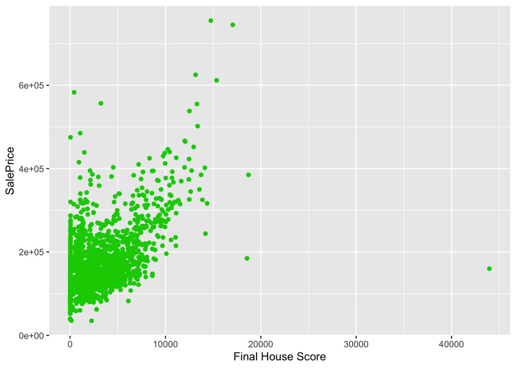

```r
ggplot(housesgroup4, aes(y=SalePrice, x=ScoreSum)) +
  geom_point(color="green3") +
  labs(x="Final House Score")
```

```r
#wow that does NOT look linear or like it has constant variance
#I need to figure out how to create a line for each variable used in the model
```

### validate

I’m not exactly sure how use the code provided for validation because it’s different than the one we used on the rbdata. I’m not sure if there’s supposed to be something after “keep,” before the ], and I’m not sure if I’m supposed to set train equal to my data, or if it is a keyword that i’m supposed to have loaded a library for (it won’t knit with the word train because it doesn’t know what it’s referencing either.)

I probably just don’t know bc I haven’t been to class in a few weeks. I just wanted to explain what part I was confused about though.

```r
# set.seed(121)
#
# num_rows <- 1000 #1460 total
# keep <- sample(1:nrow(train), num_rows)
#
# mytrain <- train[keep, ] #Use this in the lm(..., data=mytrain)
#
# mytest <- train[-keep, ] #Use this in the predict(..., newdata=mytest)
```

### temporary conclusion

this is very much a rough draft but it’s better than nothing the best lm I created was lm 21 bc all the terms are very significant and the $R^2$ is okay (0.72)

```r
grouplm11 <- lm(SalePrice ~
                 OverallAve:BsmtFinSF1 +
                  OverallAve:WoodDeckSF +
                  OverallAve:NbhdPR +
                  OverallAve:NotSingleStory +
                  OverallAve:LotShapeReg +
                  OverallAve:FeatureQualAve,
               data=housesGroup)
summary(grouplm11) %>%
  pander()
```

|  | Estimate | Std. Error | t value | Pr(>\|t\|) |
| --- | --- | --- | --- | --- |
| **(Intercept)** | 10130 | 5027 | 2.015 | 0.04409 |
| **OverallAve:BsmtFinSF1** | 4.306 | 0.4147 | 10.38 | 2.084e-24 |
| **OverallAve:WoodDeckSF** | 9.493 | 1.528 | 6.213 | 6.765e-10 |
| **OverallAve:NbhdPR** | 5033 | 313 | 16.08 | 1.143e-53 |
| **OverallAve:NotSingleStory** | 1755 | 377.8 | 4.645 | 3.703e-06 |
| **OverallAve:LotShapeReg** | -1602 | 394.3 | -4.062 | 5.123e-05 |
| **OverallAve:FeatureQualAve** | 7562 | 257.7 | 29.34 | 4.977e-149 |

Fitting linear model: SalePrice ~ OverallAve:BsmtFinSF1 + OverallAve:WoodDeckSF + OverallAve:NbhdPR + OverallAve:NotSingleStory + OverallAve:LotShapeReg + OverallAve:FeatureQualAve

| Observations | Residual Std. Error | $R^2$ | Adjusted $R^2$ |
| --- | --- | --- | --- |
| 1460 | 41792 | 0.7244 | 0.7233 |